# Gradient Descent

This is the blogpost for introducing the lecture 13 of October 18th on the topic of Gradient Descent.

## Simple Gradient Descent

Previously we have learned some concepts of machine lerning functions like linear reression and logistic regression. What remains is how we can get the minimum of $\theta$ for a function $f(\theta)$. Therefore, the goal of gradient descent is to find a $\theta^*$ such that $f(\theta^*) = \min_{\theta} f(\theta)$.  
The following describe the general algorithm of the solutions for it:

- start from initial guess $\theta^0$ and a learning rate $\alpha$
- update $\theta^{i+1} \leftarrow \theta^i - \alpha\frac{df(\theta)}{d\theta}$
- repeat until change in $\theta$ is small, or a maximum number of steps is reached

The following illustration shows how minimum is reached through updating $\theta$ with the learning rate in one parameter.

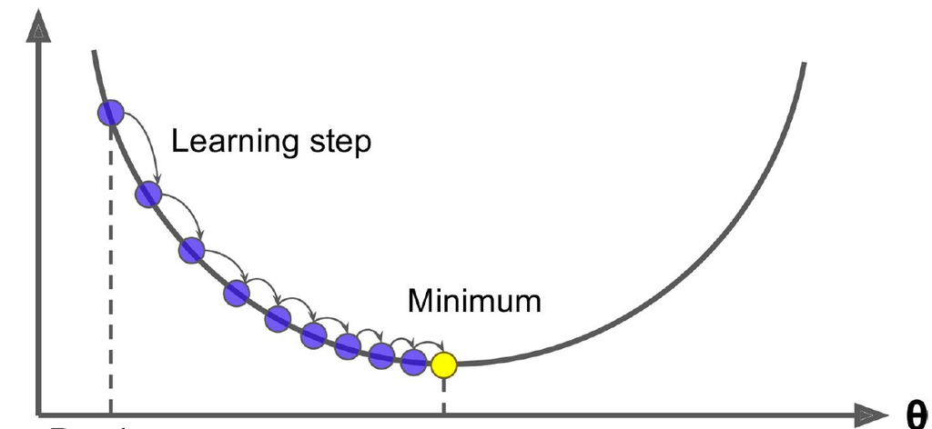

## More complicated Gradient Descent

Gradient descent with multiple parameters follows a similar idea. The difference is that now $\theta$ is not a single parameter anymore, but it becomes a vector with multiple parameters. Our goal then becomes $\min_{\theta_1,\theta_2,...,\theta_n} f(\theta_1,\theta_2,...,\theta_n)$. We also need the gradient vector of f, which is the partial derivative of f with respect to the variables respectively.  
The following describe the general algorithm of the solutions for multiple parameters:

- start from initial guess $\vec{\theta}^0$ and a learning rate $\alpha$
- update $\vec{\theta}^{i+1} \leftarrow \vec{\theta}^i - \alpha\nabla f(\vec{\theta})$, where the $\nabla f(\vec{\theta})$ is the gradient vector and is $(\dfrac{\partial f}{\partial \theta_1},\dfrac{\partial f}{\partial \theta_2},...,\dfrac{\partial f}{\partial \theta_n})$
- repeat until change in $\theta$ is small, or a maximum number of steps is reached

The following illustration shows how local minimum is reached through updating $\theta$ with the learning rate in multiple parameters.

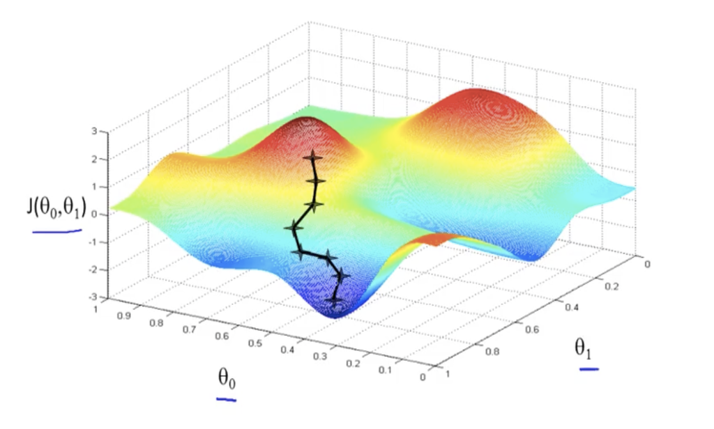

## Gradient Descent for Machine Learning

The gradient descent algorithm for machine learning in general is just adding a $D$ to the function where $D$ is the loss function. For example, for linear regression, $D$ is $(X^T\theta - Y)^2$, other parts are pretty much the same.  
The following describe the general algorithm of the solutions for multiple parameters:

- start from initial guess $\vec{\theta}^0$ and a learning rate $\alpha$
- update $\vec{\theta}^{i+1} \leftarrow \vec{\theta}^i - \alpha\nabla f(\vec{\theta}, D)$
- repeat until change in $\theta$ is small, or a maximum number of steps is reached

## Problem of Gradient Descent

Note, I mentioned "local" minimum can be reached in the illustration for gradient descent of multiple parameters above. This has a reason.  
It is because by simply doing the above algorithms, the absolute minimum is not guaranteed. We can only find the local minimum in both linear and multi-dimentional gradient descent. Therefore, we would need other methods for achieving finding an absolute minimum.

## Solutions

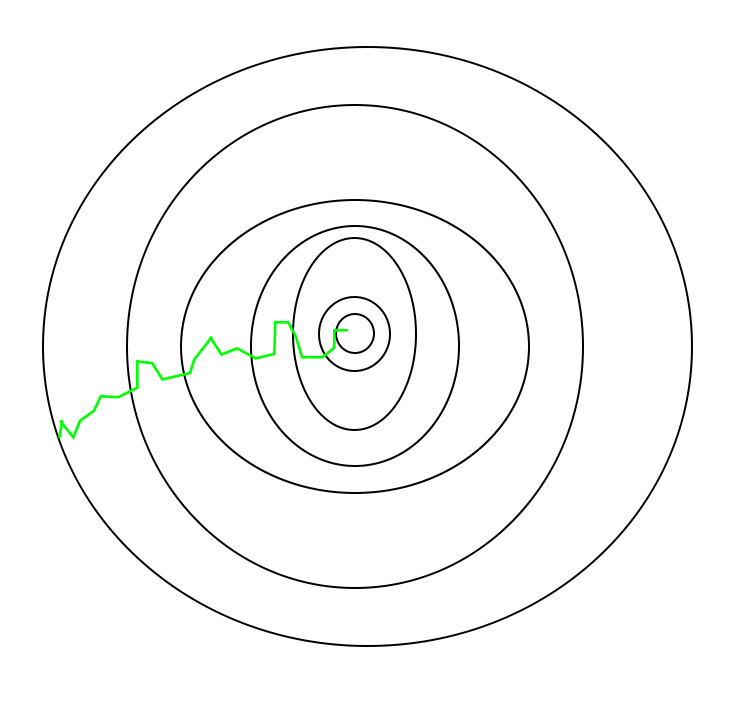